# Red Wine Quality EDA

Lucas Moura Veloso

13 de março de 2019

# 1 Introdução

Este documento trata de uma análise exploratória de dados da base de dados [Red Wine Quality](https://s3.amazonaws.com/udacity-hosted-downloads/ud651/wineQualityReds.csv), cuja descrição dos pode ser encontrada [aqui](https://s3.amazonaws.com/udacity-hosted-downloads/ud651/wineQualityInfo.txt).

Este documento foi desenvolvido para o trabalho final de EDA do programa de *Nanodegree* da Udacity.

# 2 Análise dos dados

Esta seção trata da análise dos dados e de algumas conclusões que foram tiradas durante o processo.

## 2.1 Configuração inicial

Inicialmente devemos configurar o *workspace* e a importação de bibliotecas de uso geral neste trabalho.

```r
# Carregando bibliotecas -------------------------

options(warn=-1)

library(ggplot2)
library(knitr)
library(purrr)
library(tidyr)
library(gridExtra)

require(lattice)
# Configurando o workspace -------------------------

setwd("E:/Pessoal/Udacity Nanodegree Data Science/eda-final-project")

# Lendo o arquivo de dados -------------------------

wines <- read.csv("wineQualityReds.csv", header=TRUE)
colnames(wines) <- c('fixed_acidity', 'volatile_acidity', 'citric_acid',
                     'residual_sugar', 'chlorides', 'free_sulfur_dioxide',
                     'total_sulfur_dioxide', 'density', 'pH', 'sulphates',
                     'alcohol', 'quality')
```

## 2.2 Análise inicial dos dados

A estrutura de variáveis do conjunto de dados é a seguinte:

```r
# Exibindo os dados em formatdo de tabela -------------------------

kable(head(wines), format = "markdown")
```

| fixed_acidity | volatile_acidity | citric_acid | residual_sugar | chlorides | free_sulfur_dioxide | total_sulfur_dioxide | density | pH | sulphates | alcohol | quality | NA |
| --- | --- | --- | --- | --- | --- | --- | --- | --- | --- | --- | --- | --- |
| 1 | 7.4 | 0.70 | 0.00 | 1.9 | 0.076 | 11 | 34 | 0.9978 | 3.51 | 0.56 | 9.4 | 5 |
| 2 | 7.8 | 0.88 | 0.00 | 2.6 | 0.098 | 25 | 67 | 0.9968 | 3.20 | 0.68 | 9.8 | 5 |
| 3 | 7.8 | 0.76 | 0.04 | 2.3 | 0.092 | 15 | 54 | 0.9970 | 3.26 | 0.65 | 9.8 | 5 |
| 4 | 11.2 | 0.28 | 0.56 | 1.9 | 0.075 | 17 | 60 | 0.9980 | 3.16 | 0.58 | 9.8 | 6 |
| 5 | 7.4 | 0.70 | 0.00 | 1.9 | 0.076 | 11 | 34 | 0.9978 | 3.51 | 0.56 | 9.4 | 5 |
| 6 | 7.4 | 0.66 | 0.00 | 1.8 | 0.075 | 13 | 40 | 0.9978 | 3.51 | 0.56 | 9.4 | 5 |

Plotando cada variável separadamente temos os seguintes resultados:

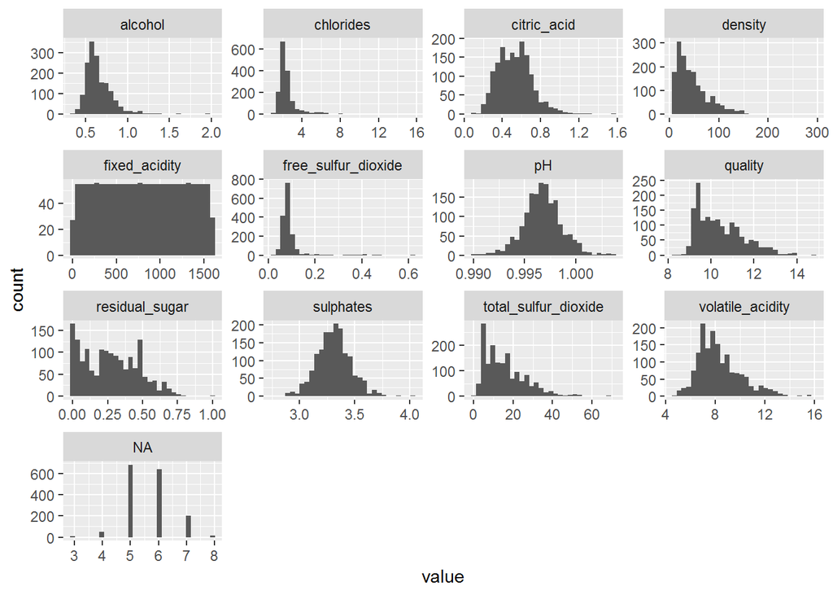

```r
# Plotando um histograma de todas as variáveis -------------------------

wines %>%
  keep(is.numeric) %>%
  gather() %>%
  ggplot(aes(value)) +
    facet_wrap(~ key, scales = "free") +
    geom_histogram()
```

As variáveis do conjunto de dados todas tem distribuições de formas muito discrepantes, porém as realacionadas com os aspectos químicos do vinho tendem a ter uma distribuição próxima da normal.

## 2.3 Correlacionando as variáveis

Plotando a matriz de correlação entre as variáveis, temos o seguinte resultado:

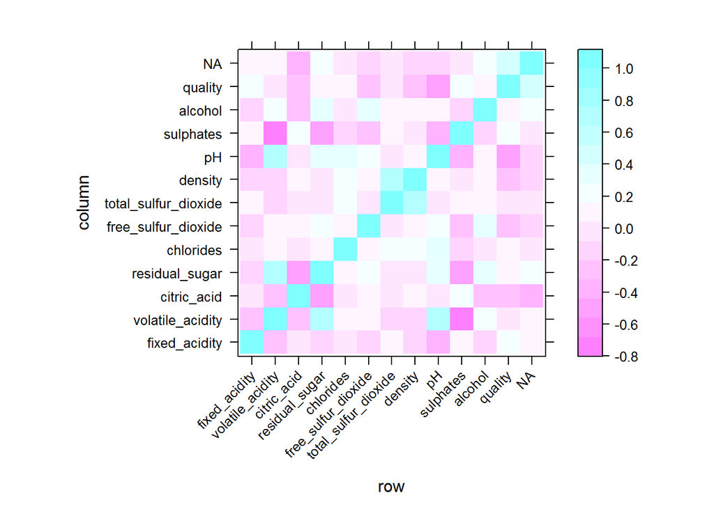

```r
# Plotando a matriz de correlação das variáveis -------------------------

wines.correlation <- cor(wines)
levelplot(wines.correlation, scale=list(x=list(rot=45)))
```

Podemos perceber que temos uma correlação positiva forte entre as variáveis `pH` e `volatile_acidity`, `density` e `total_sulfur_dioxide`, e uma correlação positiva mais fraca entre `residual_sugar` e `volatile_acidity`.

Plotando as correlações que percebemos anteriormente como positivas e forters, temos os seguintes gráficos:

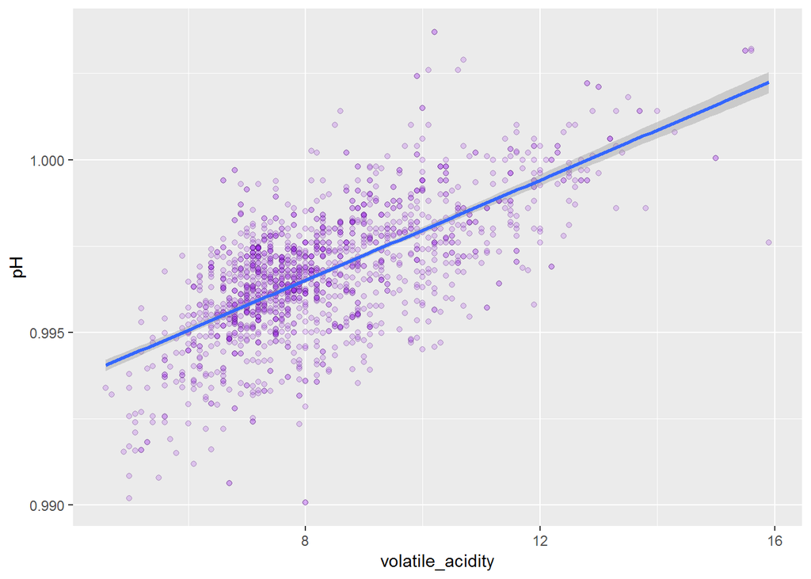

```r
# Plotando a variável pH contra volatile_acidty  -------------------------

ggplot(wines, aes(x = volatile_acidity, y = pH)) +
  geom_point(fill = I('purple'), color = 'black', shape = 21, alpha = 1/5) +
  stat_smooth(method = 'lm')
```

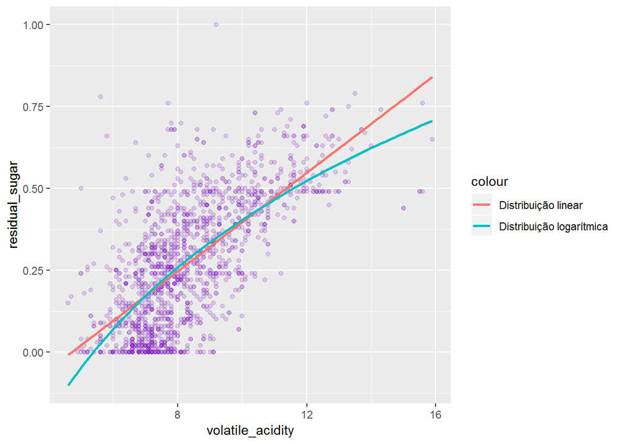

```r
# Plotando a variável volatile_acidity contra residual_sugar -----------------

ggplot(wines, aes(x = volatile_acidity, y = residual_sugar)) +
  geom_point(fill = I('purple'), color = 'black', shape = 21, alpha = 1/5) +
  stat_smooth(method = 'lm', aes(colour = 'Distribuição linear'), se = FALSE) +
  stat_smooth(method = 'nls', formula = y ~ a * log(x) +b,
            aes(colour = 'Distribuição logarítmica'), se = FALSE,
            start = list(a=1,b=1))
```

Plotando as variáveis `residual_sugar` e `pH`, que estão ambas correlacionadas à `volatile_acidity`, uma contra a outra, obtemos o seguinte resultado:

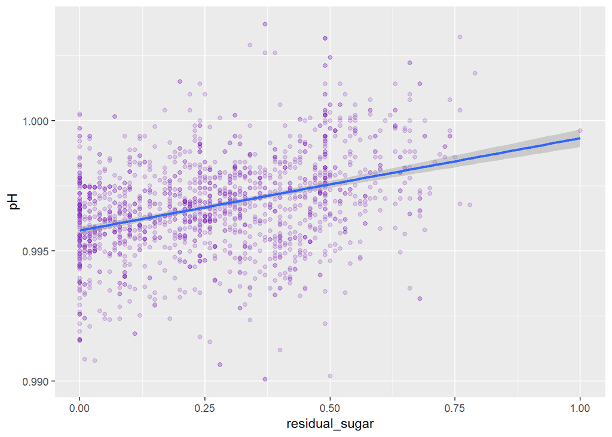

```r
# Ploando a variáveil pH contra residual_sugar -------------------------

ggplot(wines, aes(x = residual_sugar, y = pH)) +
  geom_point(fill = I('purple'), color = 'black', shape = 21, alpha = 1/5) +
  stat_smooth(method = 'lm')
```

A distribuição acima se assemelha à uma linear mas não podemos afirmar isso devido ao elevado nível de disperssão dos dados. Analisando melhor o gráfico podemos ver 3 regiões distintas de agrupamento, utilizando o algotírmo *k-means* nestas duas variáveis temos os seguintes *clusters*:

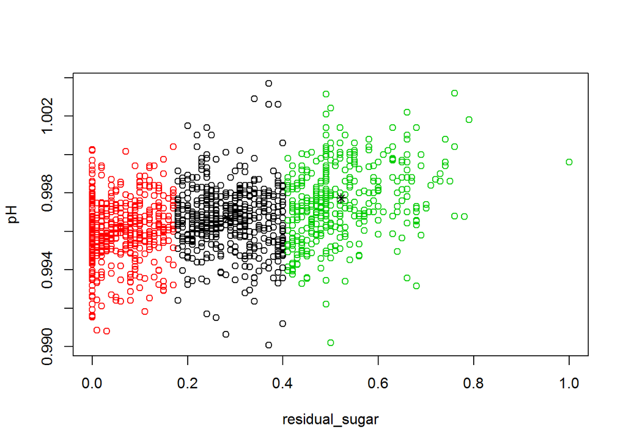

```r
# Gerando os clusters -------------------------

wines_sugar_pH <- wines[ , (names(wines) %in% c('residual_sugar', 'pH'))]
km_wines_sugar_pH <- kmeans(wines_sugar_pH, center=3)

# Plotando os clusters -------------------------

plot(wines_sugar_pH,col=km_wines_sugar_pH$cluster)
points(km_wines_sugar_pH$center,col=1:2,pch=8,cex=1)
```

Os *clusters* encontrados variam basicamente com o percentual de açucar residual do vinho e são distribuídos da seguinte forma:

1. `residual_sugar ≤ 0.2`, trata dos vinhos com pouco açúcar residual e apresenta pouca variação de pH, exceto pelos vinhos com açúcar residual aproximadamente igual à 0, neste caso o pH pode variar entre os extremos.
2. `0.2 < residual_sugar ≤ 0.4`, trata dos vinhos com açúcar residual médio, estes tendem a permanecer na faixa `0.994 < pH < 0.0998`.
3. `residual_sugar > 0.4`, vinhos com muito açúcar residual, estes apresentam a maior variabilidade de pH, podendo ser tanto os mais ácidos quanto os mais básicos.

Plotando as variáveis corerlacionadas `density` e `total_sulfur_dioxide`, geramos o seguinte gráfico:

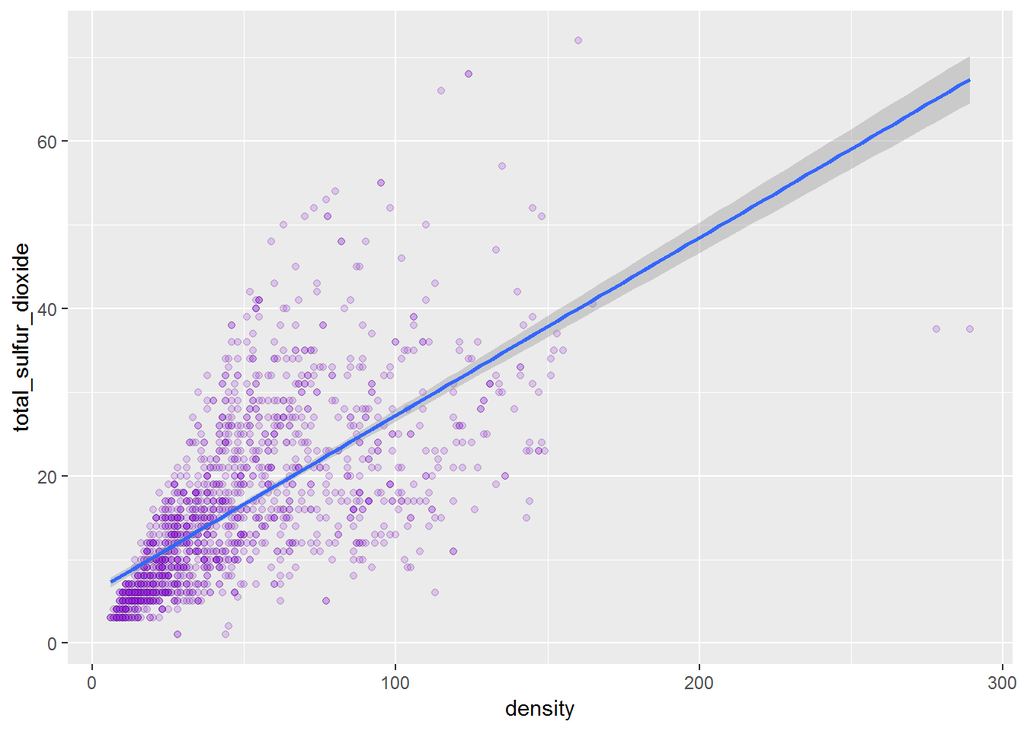

```r
# Plotando a variável density contra total_sulfur_dioxide --------------------

ggplot(wines, aes(x = density, y = total_sulfur_dioxide)) +
  geom_point(fill = I('purple'), color = 'black', shape = 21, alpha = 1/5) +
  stat_smooth(method = 'lm')
```

A relação entre o dióximo de enxofre presente e a densidade do vinho é interessante, enquanto na região inicial do gráfico temos uma forte linearidade, ao caminharmos tanto no eixo horizontal quanto no vertical esta linearidade se perde.

Podemos entender que estas variáveis são correlacionadas dentro do limite do agrupamento inicial e que vinhos com características mais distintas não possuem uma correlação tão forte, indicando dois possível *clusters* nos dados.

Vamos prosseguir esta análise utilizando o algorítmo *k-means* com 2 centros para avaliar a relação entre estas duas variáveis.

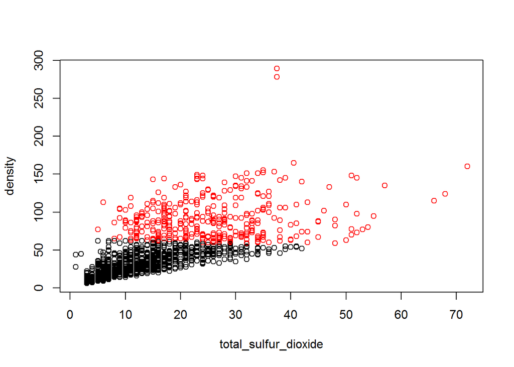

```r
# Gerando os clusters -------------------------

wines_sulfur_density <-
  wines[ , (names(wines) %in% c('density', 'total_sulfur_dioxide'))]
km_wines_sulfur_density <- kmeans(wines_sulfur_density, center=2)

# Plotando os clusters -------------------------

plot(wines_sulfur_density,col=km_wines_sulfur_density$cluster)
points(km_wines_sulfur_density$center,col=1:2,pch=8,cex=1)
```

Como podemos ver no gráfico acima, temos dois agrupamentos distintos de vinhos basicamente delineados pela linha de `density = 50`:

1. `density ≤ 50`, existe uma correlação forte entre quantidade de enxofre total e densidade do vinho.
2. `density > 50`, não possui esta característica de forma tão marcante.

## 2.4 Relacionando qualidade com outras características

Nesta seção iremos relacionar o parâmetro qualidade com as outras características do nosso conjunto de dados para tentarmos encontrar alguma relação entre esta e as demais, de modo a tentar encontrar as melhores características para auxiliar a selecionar vinhos na hora da compra.

### 2.4.1 Acidez fixa

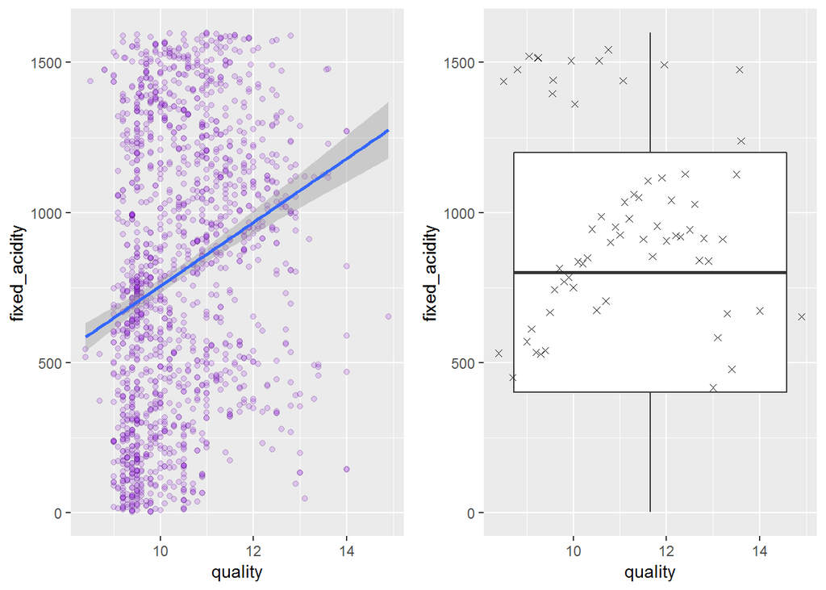

```r
# Plotando um gráfico de pontos e um de caixa de quality contra
# fixed_acidity lado a lado

plot1 <- ggplot(wines, aes(x = quality, y = fixed_acidity)) +
  geom_point(fill = I('purple'), color = 'black', shape = 21, alpha = 1/5) +
  stat_smooth(method = 'lm')
plot2 <- ggplot(wines, aes(x = quality, y = fixed_acidity)) +
  geom_boxplot() +
  stat_summary(fun.y = mean, geom='point', shape = 4)
grid.arrange(plot1, plot2, ncol=2)
```

Esta é a variável que apresenta maior variação com relação à qualidade do vinho, não é possível encontrar um padrão entre estas duas características.

### 2.4.2 Acidez volátil

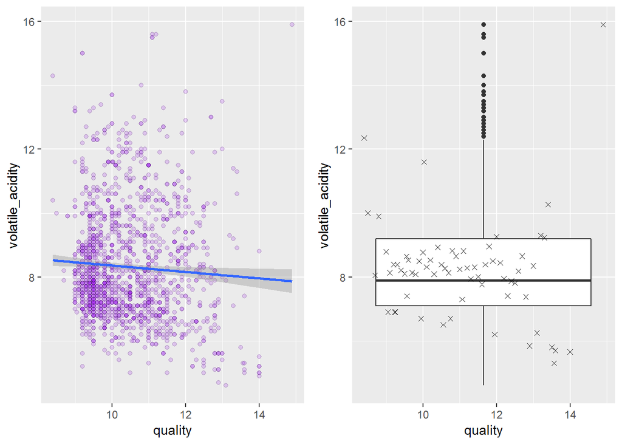

```r
# Plotando um gráfico de pontos e um de caixa de quality contra
# volatile_acidity lado a lado

plot1 <- ggplot(wines, aes(x = quality, y = volatile_acidity)) +
  geom_point(fill = I('purple'), color = 'black', shape = 21, alpha = 1/5) +
  stat_smooth(method = 'lm')
plot2 <- ggplot(wines, aes(x = quality, y = volatile_acidity)) +
  geom_boxplot() +
  stat_summary(fun.y = mean, geom='point', shape = 4)
grid.arrange(plot1, plot2, ncol=2)
```

Assim como a acidez fixa, a acidez volátil não parece ter uma relação direta com a qualidade, porém apresenta uma variação muito menor do que a sua contraparte.

### 2.4.3 Ácido crítrico

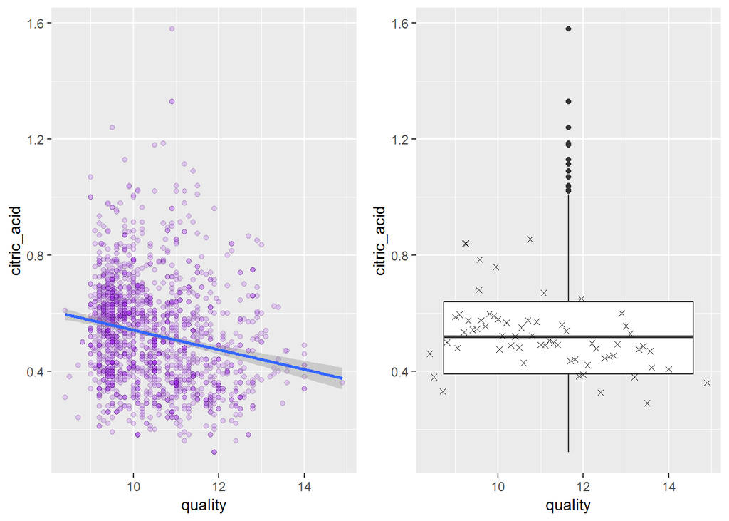

```r
# Plotando um gráfico de pontos e um de caixa de quality contra
# citric_acid lado a lado

plot1 <- ggplot(wines, aes(x = quality, y = citric_acid)) +
  geom_point(fill = I('purple'), color = 'black', shape = 21, alpha = 1/5) +
  stat_smooth(method = 'lm')
plot2 <- ggplot(wines, aes(x = quality, y = citric_acid)) +
  geom_boxplot() +
  stat_summary(fun.y = mean, geom='point', shape = 4)
grid.arrange(plot1, plot2, ncol=2)
```

A quantidade de ácido cítrico parece ter uma fraca relação linear decrescente com a qualidade, quando desconsideramos os valores discrepantes.

Podemos perceber um agrupamento grande de vinhos com os valores `0.4 ≤ citric_acid ≤ 0.8` e `8 ≤ quality ≤ 10`, similar ao encontrado na análise da característica *acidez volátil*.

### 2.4.4 Açúcar residual

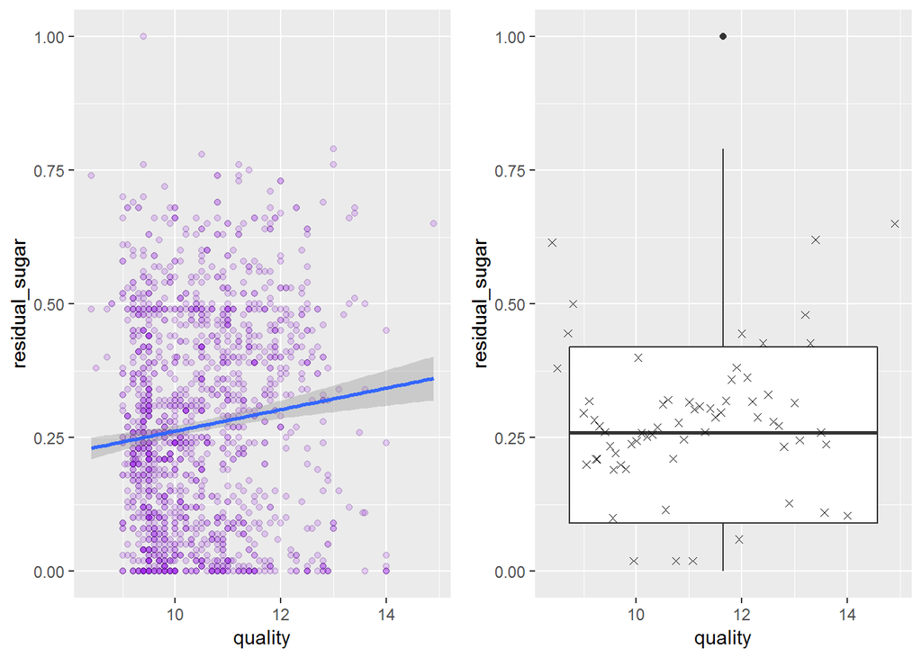

```r
# Plotando um gráfico de pontos e um de caixa de quality contra
# residual_sugar lado a lado

plot1 <- ggplot(wines, aes(x = quality, y = residual_sugar)) +
  geom_point(fill = I('purple'), color = 'black', shape = 21, alpha = 1/5) +
  stat_smooth(method = 'lm')
plot2 <- ggplot(wines, aes(x = quality, y = residual_sugar)) +
  geom_boxplot() +
  stat_summary(fun.y = mean, geom='point', shape = 4)
grid.arrange(plot1, plot2, ncol=2)
```

Não parece exitir uma relação entre o açúcar residual e a qualidade do vinho, e podemos perceber pelo gráfico de caixa que esta possui uma variabilidade bem grande.

### 2.4.5 Cloretos

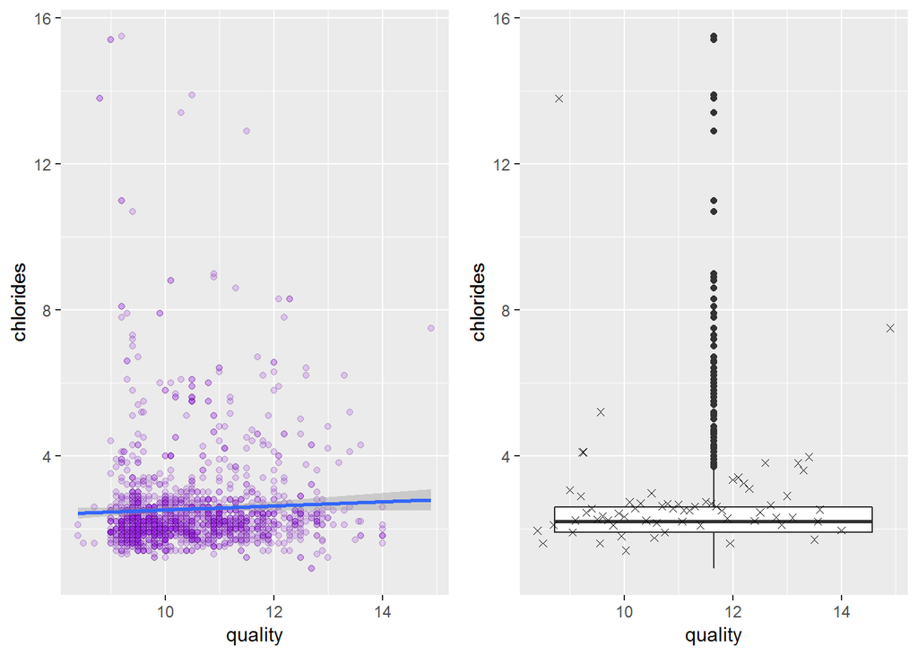

```r
# Plotando um gráfico de pontos e um de caixa de quality contra
# chlorides lado a lado

plot1 <- ggplot(wines, aes(x = quality, y = chlorides)) +
  geom_point(fill = I('purple'), color = 'black', shape = 21, alpha = 1/5) +
  stat_smooth(method = 'lm')
plot2 <- ggplot(wines, aes(x = quality, y = chlorides)) +
  geom_boxplot() +
  stat_summary(fun.y = mean, geom='point', shape = 4)
grid.arrange(plot1, plot2, ncol=2)
```

Esta variável parece não variar muito, apesar de ter alguns valores muito discrepantes do resto. Existe uma certa linearidade com a qualidade do vinho, mas não muito forte.

### 2.4.6 Dióxido de enxofre livre

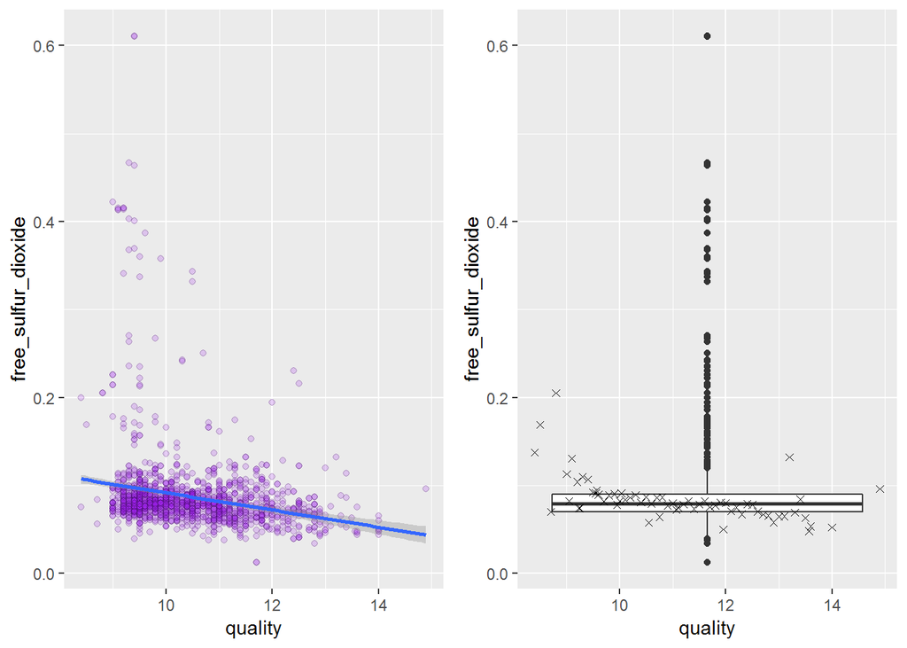

```r
# Plotando um gráfico de pontos e um de caixa de quality contra
# free_sulfur_dioxide lado a lado

plot1 <- ggplot(wines, aes(x = quality, y = free_sulfur_dioxide)) +
  geom_point(fill = I('purple'), color = 'black', shape = 21, alpha = 1/5) +
  stat_smooth(method = 'lm')
plot2 <- ggplot(wines, aes(x = quality, y = free_sulfur_dioxide)) +
  geom_boxplot() +
  stat_summary(fun.y = mean, geom='point', shape = 4)
grid.arrange(plot1, plot2, ncol=2)
```

O dióxido de enxofre livre parece estar relacionado com a qualidade do vinho de forma linear decrescente. A variabilidade desta característica é bem baixa quando desconsideramos os valores discrepantes.

### 2.4.7 Dióxido de enxofre total

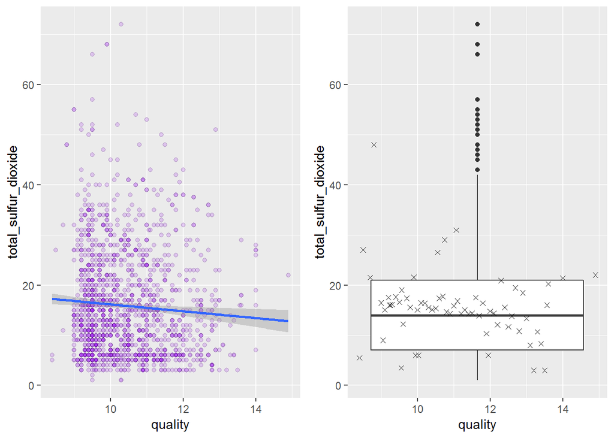

```r
# Plotando um gráfico de pontos e um de caixa de quality contra
# total_sulfur_dioxide lado a lado

plot1 <- ggplot(wines, aes(x = quality, y = total_sulfur_dioxide)) +
  geom_point(fill = I('purple'), color = 'black', shape = 21, alpha = 1/5) +
  stat_smooth(method = 'lm')
plot2 <- ggplot(wines, aes(x = quality, y = total_sulfur_dioxide)) +
  geom_boxplot() +
  stat_summary(fun.y = mean, geom='point', shape = 4)
grid.arrange(plot1, plot2, ncol=2)
```

Ao contrário do dióxido de enxofre livre, o dióxido de enxofre total não parece ter uma relação com a qualidade do vinho e apresenta uma variabilidade realativamente alta, mesmo desconsiderando os valores discrepantes.

### 2.4.8 Densidade

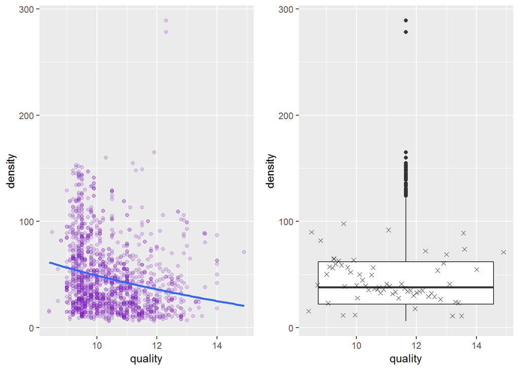

```r
# Plotando um gráfico de pontos e um de caixa de quality contra
# density lado a lado

plot1 <- ggplot(wines, aes(x = quality, y = density)) +
  geom_point(fill = I('purple'), color = 'black', shape = 21, alpha = 1/5) +
  stat_smooth(method = 'nls',
              formula = y ~ a * log(x) +b, se = FALSE,
              start = list(a=1,b=1))
plot2 <- ggplot(wines, aes(x = quality, y = density)) +
  geom_boxplot() +
  stat_summary(fun.y = mean, geom='point', shape = 4)
grid.arrange(plot1, plot2, ncol=2)
```

A densidade parece possuir uma linha de tendência logarítmica decrescente quando relacionada com a qualidade, onde os principais conjuntos de valores permanecem abaixo da mesma.

### 2.4.9 pH

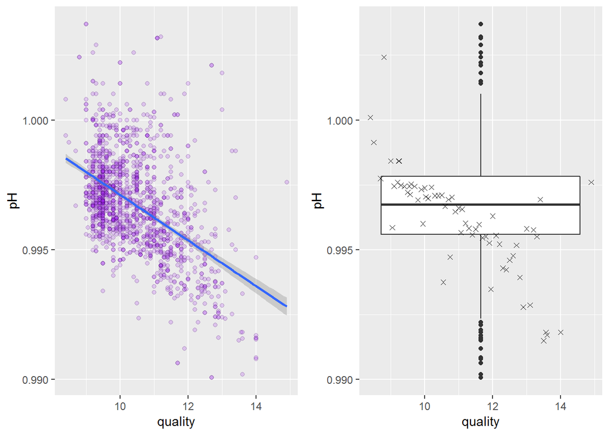

```r
# Plotando um gráfico de pontos e um de caixa de quality contra
# pH lado a lado

plot1 <- ggplot(wines, aes(x = quality, y = pH)) +
  geom_point(fill = I('purple'), color = 'black', shape = 21, alpha = 1/5) +
  stat_smooth(method = 'lm')
plot2 <- ggplot(wines, aes(x = quality, y = pH)) +
  geom_boxplot() +
  stat_summary(fun.y = mean, geom='point', shape = 4)
grid.arrange(plot1, plot2, ncol=2)
```

### 2.4.10 Sulfatos

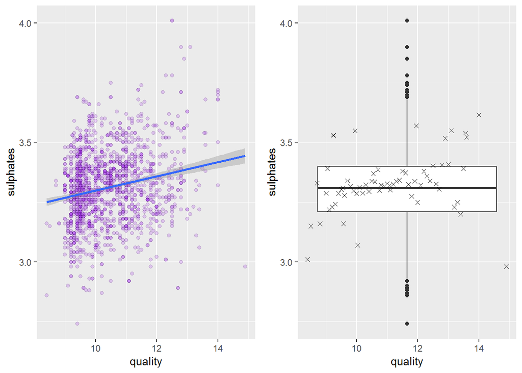

```r
# Plotando um gráfico de pontos e um de caixa de quality contra
# sulphates lado a lado

plot1 <- ggplot(wines, aes(x = quality, y = sulphates)) +
  geom_point(fill = I('purple'), color = 'black', shape = 21, alpha = 1/5) +
  stat_smooth(method = 'lm')
plot2 <- ggplot(wines, aes(x = quality, y = sulphates)) +
  geom_boxplot() +
  stat_summary(fun.y = mean, geom='point', shape = 4)
grid.arrange(plot1, plot2, ncol=2)
```

Não parece haver nenhuma relação entre os sulfatos e a qualiade do vinho. Podemos notar pelo gráfico de caixa que esta caractetrística não possui uma variabilidade muito alta, quando comparada com as outras deste mesmo conjunto de dados.

### 2.4.11 Percentual de álcool

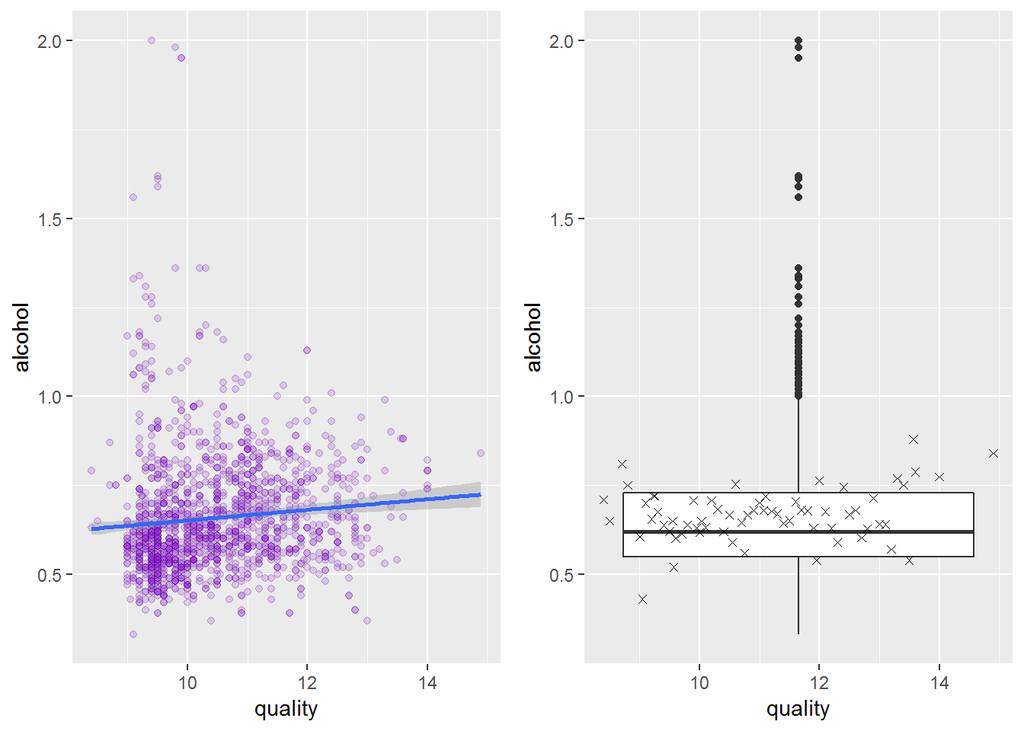

```r
# Plotando um gráfico de pontos e um de caixa de quality contra
# alcohol lado a lado

plot1 <- ggplot(wines, aes(x = quality, y = alcohol)) +
  geom_point(fill = I('purple'), color = 'black', shape = 21, alpha = 1/5) +
  stat_smooth(method = 'lm')
plot2 <- ggplot(wines, aes(x = quality, y = alcohol)) +
  geom_boxplot() +
  stat_summary(fun.y = mean, geom='point', shape = 4)
grid.arrange(plot1, plot2, ncol=2)
```

A qualidade parece se manter constante independente do percentual de álcool do vinho, o que seria de se esperar já que vinhos com graduações alcoolicas diferentes não necessariamente teriam uma qualidade superior ou inferior.

## 2.5 Comparando as relações encontradas com a qualidade

As variáveis que encontramos algum tipo de relação com a qualidade do vinho na seção anterior foram as seguintes:

- citric_acid
- chlorides
- free_sulfur_dioxide
- density
- pH

Para prosseguirmos com a análise comparativa destas variáveis, será necessário normalizar o nosso conjunto de dados.

```r
# Gerando um novo data frame com as variáveis selecionadas -------------------

wines_scaled_numeric =
  scale(wines[ , (names(wines) %in% c('citric_acid', 'chlorides',
                                      'free_sulfur_dioxide', 'density',
                                      'pH', 'quality'))])
wines_scaled = as.data.frame(wines_scaled_numeric, stringsAsFactors = FALSE)

# Plotando os valores iniciais do novo conjunto em forma de tabela -----------

kable(head(wines_scaled), format = "markdown")
```

| citric_acid | chlorides | free_sulfur_dioxide | density | pH | quality |
| --- | --- | --- | --- | --- | --- |
| 0.9615758 | -0.4530767 | -0.2436305 | -0.3790141 | 0.5580999 | -0.9599458 |
| 1.9668271 | 0.0434026 | 0.2238052 | 0.6241680 | 0.0282519 | -0.5845942 |
| 1.2966596 | -0.1693742 | 0.0963227 | 0.2289750 | 0.1342215 | -0.5845942 |
| -1.3840105 | -0.4530767 | -0.2648775 | 0.4113718 | 0.6640695 | -0.5845942 |
| 0.9615758 | -0.4530767 | -0.2436305 | -0.3790141 | 0.5580999 | -0.9599458 |
| 0.7381867 | -0.5240023 | -0.2648775 | -0.1966174 | 0.5580999 | -0.9599458 |

Feito isto podemos plotar todas as nossas variáveis relacionadas com a qualidade do vinho juntas:

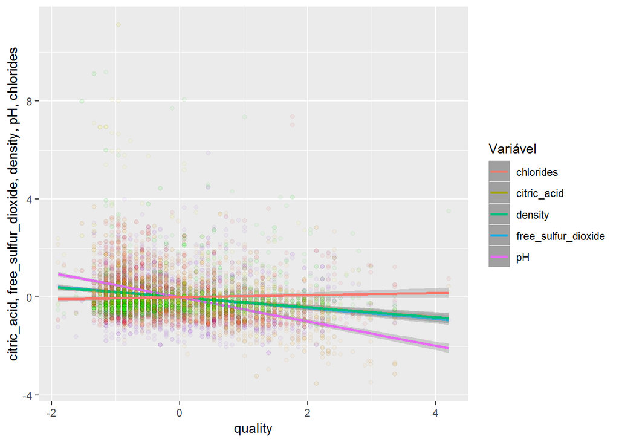

```r
# Plotando todas as variáveis relacionadas à qualidade em um único gráfico
# junto com as linhas de tendência entre os conjuntos de dados
# Todas as variáveis estão normalizadas neste gráfico.

ggplot(wines_scaled, aes(quality)) +
  geom_point(aes(y=citric_acid, colour = 'citric_acid'), fill = I('purple'),
             color = 'black', shape = 21, alpha = 1/20) +
  stat_smooth(method = 'lm', aes(y=citric_acid, colour = 'citric_acid')) +
  geom_point(aes(y=free_sulfur_dioxide, colour = 'free_sulfur_dioxide'),
             fill = I('yellow'), color = 'black', shape = 21, alpha = 1/20) +
  stat_smooth(method = 'lm', aes(y=free_sulfur_dioxide,
                                 colour = 'free_sulfur_dioxide')) +
  geom_point(aes(y=density, colour = 'density'), fill = I('red'),
             color = 'black', shape = 21, alpha = 1/20) +
  stat_smooth(method = 'lm', aes(y=density, colour = 'density')) +
  geom_point(aes(y=pH, colour = 'pH'), fill = I('orange'), color = 'black',
             shape = 21, alpha = 1/20) +
  stat_smooth(method = 'lm', aes(y=pH, colour = 'pH')) +
  geom_point(aes(y=chlorides, colour = 'chlorides'), fill = I('green'),
             color = 'black', shape = 21, alpha = 1/20) +
  stat_smooth(method = 'lm', aes(y=chlorides, colour = 'chlorides')) +
  labs(y = 'citric_acid, free_sulfur_dioxide, density, pH, chlorides',
       colour = 'Variável')
```

Como podemos perceber, temos basicamente 3 linhas diferentes, uma que envolve as variáveis `citric_acid, free_sulfur_dioxide, e density`, outra que descreve o comportamento do `pH` e outra que descreve o comportamento dos `chlorides`. Abaixo vamos analisar cada uma destes conjuntos.

### 2.5.1 Ácido cítrico, dióxido de enxofre livre e densidade

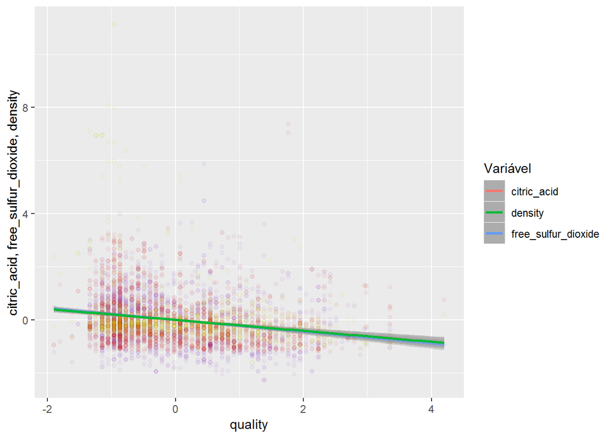

```r
# Plotando as variáveis citric_acid, free_sulfur_dioxide e density relacionadas
# à qualidade em um único gráfico junto com as linhas de tendência.
# Todas as variáveis estão normalizadas neste gráfico.

ggplot(wines_scaled, aes(quality)) +
  geom_point(aes(y=citric_acid, colour = 'citric_acid'), fill = I('purple'),
             color = 'black', shape = 21, alpha = 1/20) +
  stat_smooth(method = 'lm', aes(y=citric_acid, colour = 'citric_acid')) +
  geom_point(aes(y=free_sulfur_dioxide, colour = 'free_sulfur_dioxide'),
             fill = I('yellow'), color = 'black', shape = 21, alpha = 1/20) +
  stat_smooth(method = 'lm', aes(y=free_sulfur_dioxide,
                                 colour = 'free_sulfur_dioxide')) +
  geom_point(aes(y=density, colour = 'density'), fill = I('red'),
             color = 'black', shape = 21, alpha = 1/20) +
  stat_smooth(method = 'lm', aes(y=density, colour = 'density')) +
  labs(y = 'citric_acid, free_sulfur_dioxide, density', colour = 'Variável')
```

As três variáveis parecem ter a mesma distribuição, exceto pelos valores discrepantes, quando analisamos os seus valores normalizados, algo que não havíamos conseguido perceber anteriormente.

A relação com a qualidade do vinho parece ser linear decrescente, mas como a inclinação da reta é muito baixa, não seria muito prudente considerar esta relação como fator primário de decisão para compra de um vinho.

### 2.5.2 pH

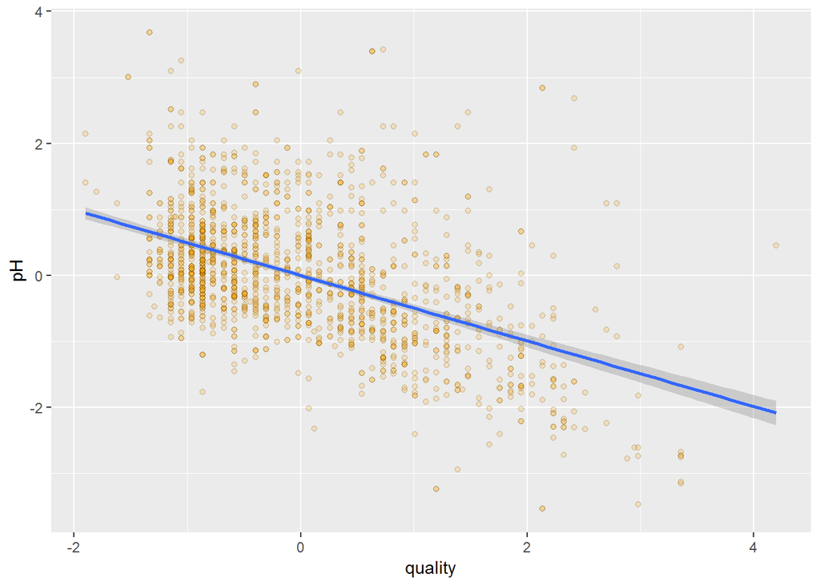

```r
# Plotando pH contra quality.
# Todas as variáveis estão normalizadas neste gráfico.

ggplot(wines_scaled, aes(quality)) +
  geom_point(aes(y=pH), fill = I('orange'), color = 'black', shape = 21,
             alpha = 1/5) +
  stat_smooth(method = 'lm', aes(y=pH))
```

Esta reta possui uma inclinação maior do que as outras analisadas e pode ser o fator mais importante para levar em consideração ao procurar um vinho.

Como encontramos anteriormente na seção `2.3` uma linearidade entre as variáveis `volatile_acidity`, e `residual_sugar` e o pH do vinho, o ideal é levarmos estas também em consideração para encontrarmos vinhos com menor pH e possivelmente maior qualidade.

### 2.5.3 Cloretos

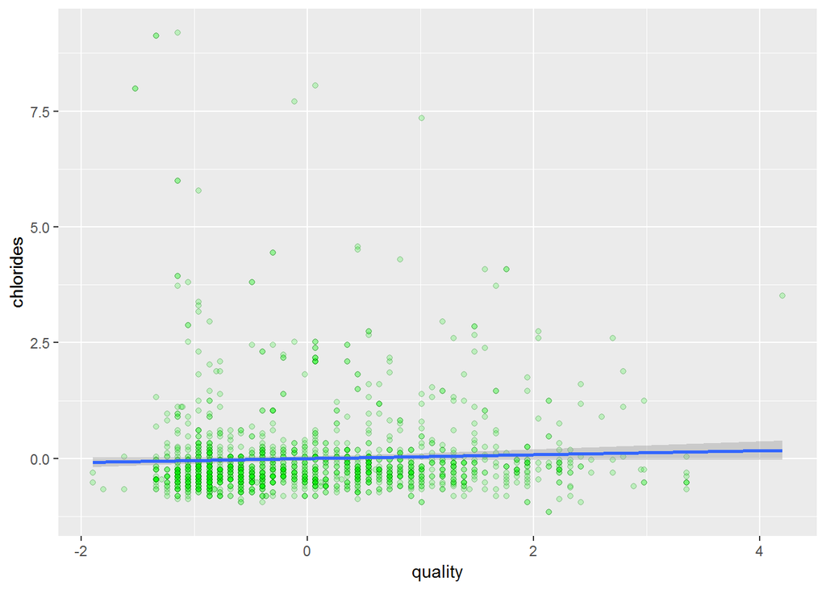

```r
# Plotando chlorides contra quality.
# Todas as variáveis estão normalizadas neste gráfico.

ggplot(wines_scaled, aes(quality)) +
  geom_point(aes(y=chlorides), fill = I('green'), color = 'black', shape = 21,
             alpha = 1/5) +
  stat_smooth(method = 'lm', aes(y=chlorides))
```

Assim como vimos na reta `citric_acid, free_sulfur_dioxide, e density`, esta é uma inclinação muito baixa e não devemos tomar esta característica como ponto principal de decisão na compra de um vinho.

# 3 Gráficos finais e sumário

Esta seção trata de três gráficos que consideramos mais interessantes durante a análise, bem como a sua explicação e contextualização.

## 3.1 Matriz de correlação das variáveis

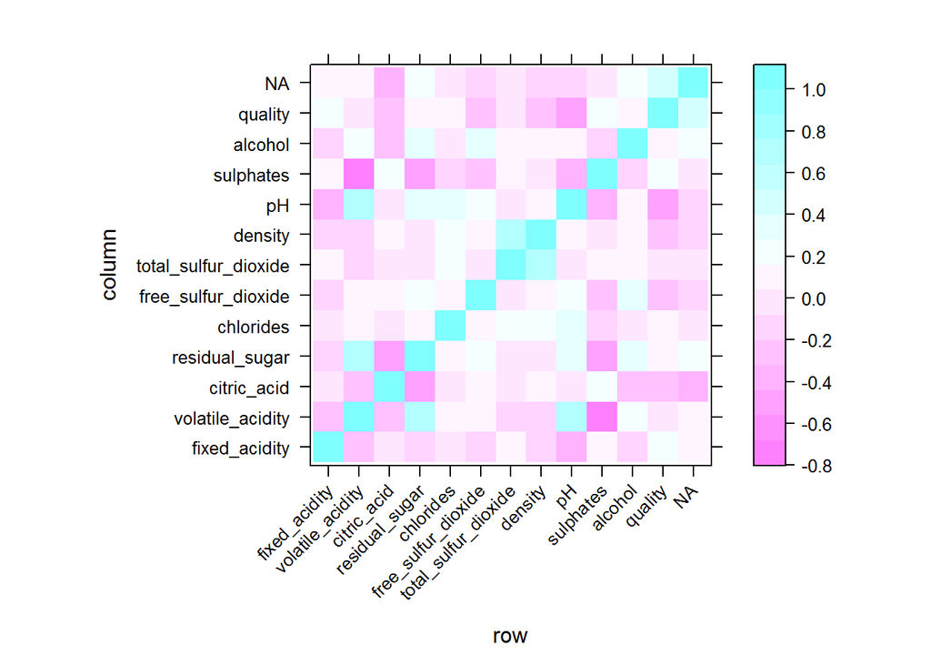

```r
# Plotando a matriz de correlação de todas as variáveis.

levelplot(wines.correlation, scale=list(x=list(rot=45)))
```

A matriz de correlação entre as variáveis foi muito importante para a análise exploratória dos dados.

Não só serve como uma fonte de informação por si só, como ajudou a dar alguns insights que foram importantes para guiar os próximos passos da análise.

## 3.2 Clusters na relação entre densidade e dióxido de enxofre total

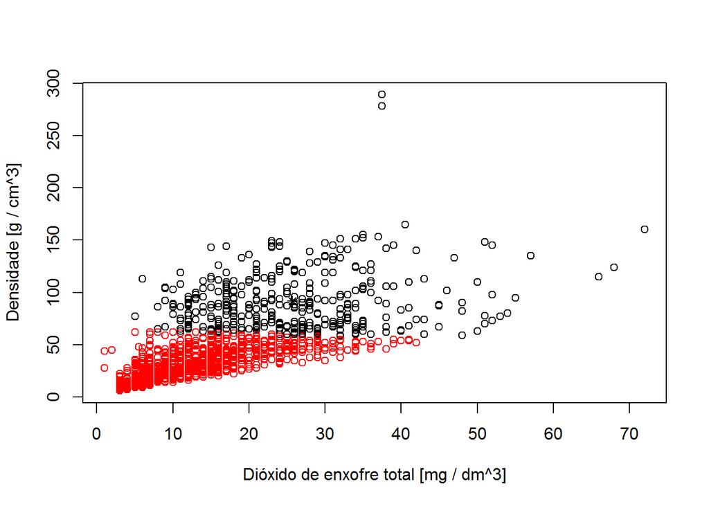

```r
# Gerando os clusters -------------------------

wines_sulfur_density <-
  wines[ , (names(wines) %in% c('density', 'total_sulfur_dioxide'))]
km_wines_sulfur_density <- kmeans(wines_sulfur_density, center=2)

# Plotando os clusters ------------------------

plot(wines_sulfur_density,col=km_wines_sulfur_density$cluster,
     xlab='Dióxido de enxofre total [mg / dm^3]',
     ylab='Densidade [g / cm^3]')
points(km_wines_sulfur_density$center,col=1:2,pch=8,cex=1)
```

Sabendo disso, criei a visualização de *clusters* acima, utilizando o algorítmo [`k-means`](https://www.rdocumentation.org/packages/Rcmdr/versions/2.0-4/topics/KMeans) configurado com dois centros.

Como podemos ver no gráfico acima, temos dois agrupamentos distintos de vinhos basicamente delineados pela linha de `density = 50`:

1. `density ≤ 50`, existe uma correlação forte e linear entre quantidade de enxofre total e densidade do vinho.
2. `density > 50`, não possui esta característica.

## 3.3 Relação entre pH e qualidade do vinho

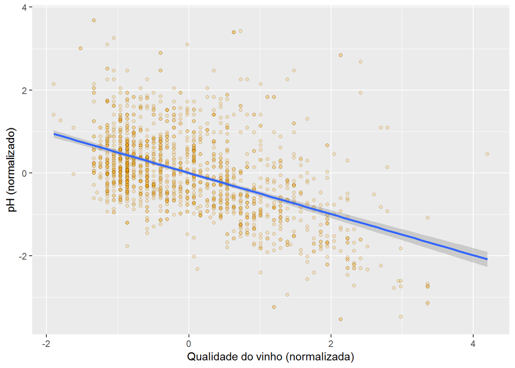

```r
# Plotando pH contra quality.
# Todas as variáveis estão normalizadas neste gráfico.

ggplot(wines_scaled, aes(quality)) +
  geom_point(aes(y=pH), fill = I('orange'), color = 'black', shape = 21,
             alpha = 1/5) +
  stat_smooth(method = 'lm', aes(y=pH)) +
  labs(y = 'pH (normalizado)', x = 'Qualidade do vinho (normalizada)')
```

Este gráfico representa a relação entre as variáveis `pH` e `quality`, de forma normalizada utilizando a função [`scale()`](https://www.rdocumentation.org/packages/base/versions/3.5.3/topics/scale).

Esta reta possui uma inclinação maior do que as outras analisadas e pode ser o fator mais importante para levar em consideração ao procurar um vinho.

Como encontramos anteriormente na seção `2.3` uma linearidade entre as variáveis `volatile_acidity`, e `residual_sugar` e o pH do vinho, o ideal é levarmos estas também em consideração para encontrarmos vinhos com menor pH e possivelmente maior qualidade.

# 4 Reflexão

Esta seção trata de algumas reflexões importantes sobre o processo de geração deste documento.

## 4.1 Onde tive dificuldades na análise?

Tive muita dificuldade em encontrar pontos para analisar, a *EDA* é um processo que requer muita criatividade e que por vezes encontramos pontos onde não temos como prosseguir.

Tentei me guiar por análises de correlação e tentar encontrar relações simples entre algumas variáveis, o que pode não ser o ideal já que estas relações podem não se provar reais em situações reais que fogem do escopo dos dados em questão.

## 4.2 Onde obtive sucessos?

Creio que obtive sucesso ao encontrar os *clusters* descritos na seção `2.3 Correlacionando as variáveis` e nas relações com a qualidade do vinho encontradas na seção `2.5 Comparando as relações encontradas com a qualidade`.

## 4.3 Como a análise poderia ser enriquecida em trabalhos futuros (e.g. dados adicionais ou análises)?

Esta análise pode ser enriquecida em trabalhos futuros se utilizarmos os resultados da seção `2.5 Comparando as relações encontradas com a qualidade` para gerar modelos preditivos de qualidade de vinho.

Também podemos explorar os pontos na matriz de correlação descrita no inicío da seção `2.3 Correlacionando as variáveis` em que existe o mínimo de correlação possível, como entre as variáveis `volatile_acidity` e `sulphates`.